# Seattle pets

Chris Shaw

30 March 2019

## Data collection

The raw dataset contains license information for registered pets in Seattle. Although some data records go back a long time, before 2017 they are sporadic. So we’ll consider only data after Jan 2017 and answer a question based on that.

This paper contains a summary of the steps and conclusion. The full analysis [can be found here](https://github.com/connectedblue/tidytuesday/blob/master/data/2019/2019-03-26/pets.Rmd).

```r
# read in the data from disk - can uncomment the line below to retrieve from github if required
#seattle_pets <- readr::read_csv("https://raw.githubusercontent.com/rfordatascience/tidytuesday/master/data/2019/2019-03-26/seattle_pets.csv")
seattle_pets <- readr::read_csv("seattle_pets.csv")


# Fix date column
# most data is after 2016
seattle_pets <- seattle_pets %>%
                mutate(license_issue_date=mdy(license_issue_date)) %>%
                filter(license_issue_date>dmy('01-01-2017'))
```

To answer this question, we’ll first determine the most popular names each quarter across species. We’ll only count names that are registered more than 5 times in a quarter. We can then see the top 5 names each quarter.

We can determine the most popular names overall by assigning a simple score to each name - the higher the rank, the higher the score. If we add up the scores over each quarter, we can use this to order the name field by, so most popular names appear at the top.

```r
# Make animal name a factor variable with levels in descending order of name_score
animal_name_order <- monthly_popular_names %>%
                         ungroup() %>%
                         group_by(animals_name) %>%
                         mutate(score=6-monthly_rank,
                                name_score=sum(score)) %>%
                         ungroup() %>%
                     select(animals_name, name_score) %>%
                     arrange(-name_score) %>%
                     distinct()

monthly_popular_names <- monthly_popular_names %>%
                         mutate(animals_name=factor(animals_name, levels = animal_name_order$animals_name))
```

Bringing all this together, we can see the distribution of the five most popular names in the following plot

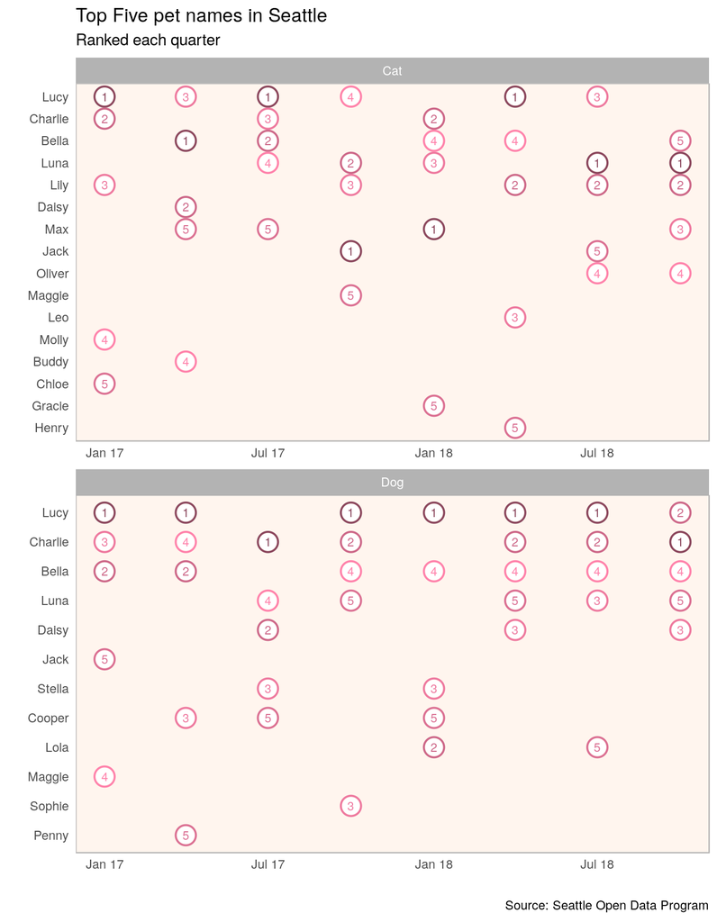

```r
library(scales)

bg <- 'seashell'


ggplot(monthly_popular_names, aes(x=month, y=reorder(animals_name, desc(animals_name)))) +
     geom_point(col='white', size=5) +
     geom_point(aes(col=factor(monthly_rank)),stroke = 1, shape=1, size=6) +
     geom_text(aes(label=monthly_rank, col=factor(monthly_rank)),hjust=0.5, vjust=0.5, nudge_x =0, size=3) +
     scale_color_manual(values=c('palevioletred4', 'palevioletred3', 'palevioletred2','palevioletred1','palevioletred')) +
     scale_x_date(labels = date_format("%b %y")) +
     facet_wrap(species~., ncol=1,scales = 'free', strip.position="top")  +
     labs(title='Top Five pet names in Seattle',
          subtitle='Ranked each quarter',
          x='',y='',
          caption='Source: Seattle Open Data Program') +
     theme_light() +
     theme(panel.grid.major = element_blank(),
           panel.grid.minor = element_blank(),
           panel.background = element_rect(fill = bg, colour = bg),
           axis.ticks = element_blank(),
           legend.position = "none"
     )
```